# Deep Learning

## Simple Linear Regression

The simplest form of machine learning is Simple Linear Regression. Below we go through an example of a linear regression problem that we will use next to discuss Gradient Descent and lead into the discussion of Deep Learning. Below is a small snippet of the dataset that we'll be working with. It is a very simple example containing 100 *x* values, along with corresponding 100 *y* values. [Source: https://github.com/llSourcell]

```python
# Load libraries
import pandas as pd
from sklearn import linear_model
from sklearn.metrics import mean_squared_error
import matplotlib.pyplot as plt
import warnings
warnings.filterwarnings('ignore')

# Read data
dataframe = pd.read_csv('LinRegData.csv')
dataframe.head()
```

|  | x | y |
| --- | --- | --- |
| 0 | 32.502345 | 31.707006 |
| 1 | 53.426804 | 68.777596 |
| 2 | 61.530358 | 62.562382 |
| 3 | 47.475640 | 71.546632 |
| 4 | 59.813208 | 87.230925 |

We will now go ahead and covert the data into the correct input format, feed it through sklearn's LinearRegression method to fit the data and produce a plot that contains the line of best fit.

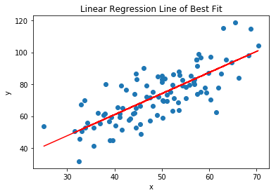

```python
# Convert data to correct format for input into the model
data = dataframe.values

# Extract x and y values
x_values = data[:,0]
y_values = data[:,1]

# Reshape data into correct format
x_values = x_values.reshape((len(x_values),1))
y_values = y_values.reshape((len(y_values),1))

# Train model on data
lin_reg = linear_model.LinearRegression()
lin_reg.fit(x_values, y_values)

# Get line of best fit
predictions = []
for i in range(0,len(x_values)):
    prediction = lin_reg.predict([x_values[i]])
    predictions.append(prediction[0][0])

# Visualize data
plt.scatter(x_values, y_values)
plt.xlabel('x')
plt.ylabel('y')
plt.title('Linear Regression Line of Best Fit')
plt.plot(x_values,predictions,'r')
plt.show()
```

Because the data is fairly linear in nature, the line of best fit does a relatively good job at fitting the data. Let`s now look at the intercept, slope and mean squared error.

```python
print('Intercept: ', lin_reg.intercept_[0])
print('Coefficient: ', lin_reg.coef_[0][0])
print('MSE: ', mean_squared_error(x_values, predictions))
```

```
Intercept:  7.991020985734465
Coefficient:  1.322431022687868
MSE:  575.1086665107362
```

## Gradient Descent

Gradient Descent is one of the methods that can be used in linear regression to update the parameters of the models during the process of fitting the model to the data. Gradient Descent is the technique used in the backpropagation step of deep learning models to update the weights. We will repeat the process above of fitting a model to the same data but this time doing the gradient descent process explicitly. We will begin by first setting our hyperparameters, defining the functions required to perform gradient descent and print out the results.

```python
# Import numpy
from numpy import *

# Hyperparameters
learning_rate = 0.0001

# y = mx + b
initial_b = 0
initial_m = 0
num_iterations = 100000

def compute_error_for_given_points(b, m, points):
    totalError = 0
    for i in range(0, len(points)):
        x = points[i, 0]
        y = points[i, 1]
        totalError += (y - (m * x + b)) **2
    return totalError / float(len(points))


def step_gradient(b_current, m_current, points, learning_rate):
    # Gradient Descent
    b_gradient = 0
    m_gradient = 0
    N = float(len(points))
    for i in range(0, len(points)):
        x = points[i, 0]
        y = points[i, 1]
        b_gradient += -(2/N) * (y - ((m_current * x) + b_current))
        m_gradient += -(2/N) * x * (y - ((m_current * x) + b_current))
    new_b = b_current - (learning_rate * b_gradient)
    new_m = m_current - (learning_rate * m_gradient)
    return [new_b, new_m]

def gradient_descent_runner(data, initial_b, initial_m, learning_rate, num_iterations):
    b = initial_b
    m = initial_m
    for i in range(num_iterations):
        b, m = step_gradient(b, m, array(data), learning_rate)
    return [b, m]

[b, m] = gradient_descent_runner(data, initial_b, initial_m, learning_rate, num_iterations)

print('Intercept: ', b)
print('Coefficient: ', m)
print('MSE: ', compute_error_for_given_points(b, m, data))
```

```
Intercept:  4.247984442217928
Coefficient:  1.3959992654908326
MSE:  110.78631928081118
```

Although not exactly the same, the results are directionally similar to those achieved above.

## Simple Feedforward Neural Network

We'll now develop a very simple feedforward neural network in order to demonstrate some of the basic principles of neural networks before moving onto more complex variations. We will use strictly numpy in this example to show the inner workings of the model before moving onto using libraries such as Tensorflow and Keras. We'll begin by defining a class for the neural network. This class will initialize the weights, define the sigmoid function along with its derivative, contain a method to train the model on existing data and a method to make predictions given new data.

```python
class NeuralNetwork():
    def __init__(self):
        # Seed the number generator
        random.seed(1)

        # We model a single neuron with 3 input connections and 1 output connection
        # We assign random weights to a 3 x 1 matrix, with values in the range -1 to 1 and mean 0
        self.synaptic_weights = 2 * random.random((3,1)) - 1

    # The sigmoid function - activation function - Normalizes weighted sum of inputs between 0 and 1
    def __sigmoid(self, x):
            return 1 / (1 + exp(-x))

     # Gradient of the sigmoid curve
    def __sigmoid_derivative(self, x):
            return x * (1 - x)

    def train(self, training_set_inputs, training_set_outputs, number_of_training_iterations):
        for iteration in range(0,number_of_training_iterations):
            # Pass the training set through our neural net
            output = self.predict(training_set_inputs)

            # Calculate the error
            error = training_set_outputs - output

            # Multiply the error by the input and again by the gradient of the sigmoid curve
            adjustment = dot(training_set_inputs.T, error * self.__sigmoid_derivative(output))

            # Adjust the weights
            self.synaptic_weights += adjustment

    def predict(self, inputs):
        # Pass inputs through our neural network (single neuron)
        return self.__sigmoid(dot(inputs, self.synaptic_weights))
```

For this demonstration case, we'll provide a very simple dataset for training and testing the model.

```python
#Initialize a single neuron neural network
neural_network = NeuralNetwork()

print('Random starting synaptic weights:')
print (neural_network.synaptic_weights)

#The training set - 4 examples consisting of 3 input values and 1 output value
training_set_inputs = array([[0,0,1], [1,1,1], [1,0,1], [0,1,1]])
training_set_outputs = array([[0,1,1,0]]).T

#Train the neural network using a training set using 10,000 iterations
neural_network.train(training_set_inputs, training_set_outputs, 10000)

print('New synaptic weights after training:')
print (neural_network.synaptic_weights)

# Test the neural network
print ('Predicting:')
print (neural_network.predict([[1,0,0]]))
```

```
Random starting synaptic weights:
[[-0.16595599]
 [ 0.44064899]
 [-0.99977125]]
New synaptic weights after training:
[[ 9.67299303]
 [-0.2078435 ]
 [-4.62963669]]
Predicting:
[[0.99993704]]
```

### Tensorflow

We will now train a deep learning model using the Tensorflow library. This will once again be a feedforward neural network in which we use stock data to make predictions. We will use the prices of stocks that are consituents of the S&P500 to predict the index price using 1-minute data. The individual stock data is lagged by one in the raw data file, which means that the pre-processing of the dataset has already been done to ensure that the training points and the labels are in the same row. [Source: https://medium.com/mlreview/a-simple-deep-learning-model-for-stock-price-prediction-using-tensorflow-30505541d877]

```python
# Import libraries
import tensorflow as tf
from sklearn.preprocessing import MinMaxScaler
import numpy as np

# Import data
data = pd.read_csv('data_stocks.csv')

# Drop date variable
data = data.drop(['DATE'], 1)

# Dimensions of dataset
n = data.shape[0]
p = data.shape[1]

# Make data a np.array
data = data.values

# Training and test data
train_start = 0
train_end = int(np.floor(0.8*n))
test_start = train_end + 1
test_end = n
data_train = data[np.arange(train_start, train_end), :]
data_test = data[np.arange(test_start, test_end), :]

# Build X and y
X_train = data_train[:, 1:]
y_train = data_train[:, 0]
X_test = data_test[:, 1:]
y_test = data_test[:, 0]

# Scale data
scalerx = MinMaxScaler(feature_range=(-1,1)).fit(X_train)
scalery = MinMaxScaler(feature_range=(-1,1)).fit(y_train)
X_train = scalerx.transform(X_train)
y_train = scalery.transform(y_train)
X_test = scalerx.transform(X_test)
y_test = scalery.transform(y_test)

# Number of stocks in training data
n_stocks = X_train.shape[1]

# Neurons
n_neurons_1 = 1024
n_neurons_2 = 512
n_neurons_3 = 256
n_neurons_4 = 128

# Session
net = tf.InteractiveSession()

# Placeholder
X = tf.placeholder(dtype=tf.float32, shape=[None, n_stocks])
Y = tf.placeholder(dtype=tf.float32, shape=[None])

# Initializers
sigma = 1
weight_initializer = tf.contrib.layers.variance_scaling_initializer(mode="FAN_AVG", uniform = True, factor=sigma)
bias_initializer = tf.zeros_initializer()

# Hidden weights
W_hidden_1 = tf.Variable(weight_initializer([n_stocks, n_neurons_1]))
bias_hidden_1 = tf.Variable(bias_initializer([n_neurons_1]))
W_hidden_2 = tf.Variable(weight_initializer([n_neurons_1, n_neurons_2]))
bias_hidden_2 = tf.Variable(bias_initializer([n_neurons_2]))
W_hidden_3 = tf.Variable(weight_initializer([n_neurons_2, n_neurons_3]))
bias_hidden_3 = tf.Variable(bias_initializer([n_neurons_3]))
W_hidden_4 = tf.Variable(weight_initializer([n_neurons_3, n_neurons_4]))
bias_hidden_4 = tf.Variable(bias_initializer([n_neurons_4]))

# Output weights
W_out = tf.Variable(weight_initializer([n_neurons_4, 1]))
bias_out = tf.Variable(bias_initializer([1]))

# Hidden layer
hidden_1 = tf.nn.relu(tf.add(tf.matmul(X, W_hidden_1), bias_hidden_1))
hidden_2 = tf.nn.relu(tf.add(tf.matmul(hidden_1, W_hidden_2), bias_hidden_2))
hidden_3 = tf.nn.relu(tf.add(tf.matmul(hidden_2, W_hidden_3), bias_hidden_3))
hidden_4 = tf.nn.relu(tf.add(tf.matmul(hidden_3, W_hidden_4), bias_hidden_4))

# Output layer (transpose!)
out = tf.transpose(tf.add(tf.matmul(hidden_4, W_out), bias_out))

# Cost function
mse = tf.reduce_mean(tf.squared_difference(out, Y))

# Optimizer
opt = tf.train.AdamOptimizer().minimize(mse)

# Init
net.run(tf.global_variables_initializer())

# Fit neural net
batch_size = 256
mse_train = []
mse_test = []

# Run
epochs = 10
for e in range(epochs):

    # Shuffle training data
    shuffle_indices = np.random.permutation(np.arange(len(y_train)))
    X_train = X_train[shuffle_indices]
    y_train = y_train[shuffle_indices]

    # Minibatch training
    for i in range(0, len(y_train) // batch_size):
        start = i * batch_size
        batch_x = X_train[start:start + batch_size]
        batch_y = y_train[start:start + batch_size]
        # Run optimizer with batch
        net.run(opt, feed_dict={X: batch_x, Y: batch_y})

        # Show progress
        if np.mod(i, 50) == 0:
            # MSE train and test
            mse_train.append(net.run(mse, feed_dict={X: X_train, Y: y_train}))
            mse_test.append(net.run(mse, feed_dict={X: X_test, Y: y_test}))
            print('MSE Train: ', mse_train[-1])
            print('MSE Test: ', mse_test[-1])
```

[output not shown]

```python
# Make prediction
X_test_single = np.array([X_test[-1,:]])
pred = net.run(out, feed_dict = {X: X_test_single})

#print(y_test[-1])
# Do inverse transform
real_actual = scalery.inverse_transform(np.array([y_test[-1]]))
real_pred = scalery.inverse_transform(pred)

print('Actual Value: ', real_actual[0])
print('Predicted Value: ', real_pred[0][0])
```

```
Actual Value:  2471.49
Predicted Value:  2464.29
```

Although not perfect, the model does a pretty good job at predicting the actual value.

Let's now use the same data as above to develop an LSTM model.

```python
# Import libraries
import numpy
import matplotlib.pyplot as plt
import pandas as pd
import math
from keras.models import Sequential
from keras.layers import Dense
from keras.layers import LSTM
from sklearn.preprocessing import MinMaxScaler
from sklearn.metrics import mean_squared_error
```

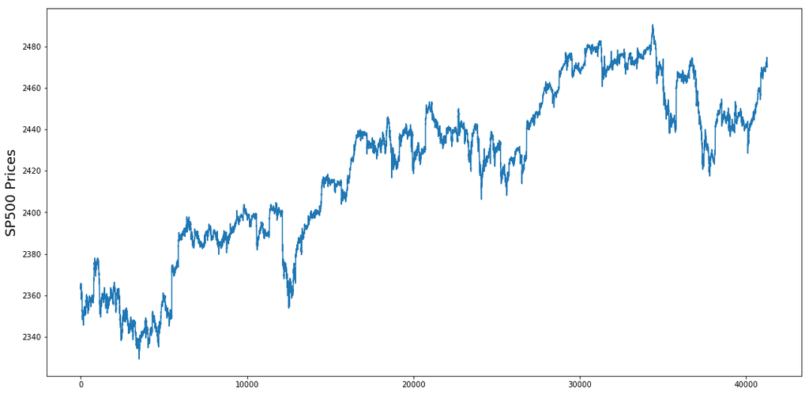

```python
# Set random seed for reproducibility
numpy.random.seed(7)

# Read data
dataframe = pd.read_csv('data_stocks.csv')
dataframe = pd.DataFrame(dataframe['SP500'])
dataset = dataframe.values
dataset = dataset.astype('float32')

# Visualize data
plt.figure(figsize = (18,9))
plt.plot(range(dataset.shape[0]),dataset)
plt.ylabel('SP500 Prices',fontsize=18)
plt.show()
```

```python
# normalize the dataset
scaler = MinMaxScaler(feature_range=(0, 1))
dataset = scaler.fit_transform(dataset)

# split into train and test sets
train_size = int(len(dataset) * 0.8)
test_size = len(dataset) - train_size
train, test = dataset[0:train_size,:], dataset[train_size:len(dataset),:]
print('Training size: ', len(train), 'Test size: ', len(test))

# convert an array of values into a dataset matrix
def create_dataset(dataset, look_back=1):
    dataX, dataY = [], []
    for i in range(len(dataset)-look_back-1):
        a = dataset[i:(i+look_back), 0]
        dataX.append(a)
        dataY.append(dataset[i + look_back, 0])
    return numpy.array(dataX), numpy.array(dataY)

# reshape into X=t and Y=t+1
look_back = 10
trainX, trainY = create_dataset(train, look_back)
testX, testY = create_dataset(test, look_back)

# reshape input to be [samples, time steps, features]
trainX = numpy.reshape(trainX, (trainX.shape[0], 1, trainX.shape[1]))
testX = numpy.reshape(testX, (testX.shape[0], 1, testX.shape[1]))

# create and fit the LSTM network
model = Sequential()
model.add(LSTM(4, input_shape=(1, look_back)))
model.add(Dense(1))
model.compile(loss='mean_squared_error', optimizer='adam')
model.fit(trainX, trainY, epochs=10, batch_size=1, verbose=2)
```

```
Training size:  33012 Test size:  8254
 - 52s - loss: 0.0011
 - 51s - loss: 3.5723e-05
 - 58s - loss: 3.0756e-05
 - 58s - loss: 2.7332e-05
 - 61s - loss: 2.5677e-05
 - 54s - loss: 2.4361e-05
 - 61s - loss: 2.3882e-05
 - 60s - loss: 2.3249e-05
 - 57s - loss: 2.2619e-05
 - 57s - loss: 2.1781e-05
```

```
<keras.callbacks.History at 0x3b8d9cc0>
```

```python
# make predictions
trainPredict = model.predict(trainX)
testPredict = model.predict(testX)
# invert predictions
trainPredict = scaler.inverse_transform(trainPredict)
trainY = scaler.inverse_transform([trainY])
testPredict = scaler.inverse_transform(testPredict)
testY = scaler.inverse_transform([testY])
# calculate root mean squared error
trainScore = math.sqrt(mean_squared_error(trainY[0], trainPredict[:,0]))
print('Train Score: %.2f RMSE' % (trainScore))
testScore = math.sqrt(mean_squared_error(testY[0], testPredict[:,0]))
print('Test Score: %.2f RMSE' % (testScore))
```

```
Train Score: 0.00 RMSE
Test Score: 0.01 RMSE
```

[figure not shown]

```python
# shift train predictions for plotting
trainPredictPlot = numpy.empty_like(dataset)
trainPredictPlot[:, :] = numpy.nan
trainPredictPlot[look_back:len(trainPredict)+look_back, :] = trainPredict
# shift test predictions for plotting
testPredictPlot = numpy.empty_like(dataset)
testPredictPlot[:, :] = numpy.nan
testPredictPlot[len(trainPredict)+(look_back*2)+1:len(dataset)-1, :] = testPredict

# Visualize data
plt.figure(figsize = (18,9))
# plot baseline and predictions
plt.plot(scaler.inverse_transform(dataset))
plt.plot(trainPredictPlot)
plt.plot(testPredictPlot)
plt.show()
```

From both the RMSE and the visual, the LSTM model does a descent job at predicting the output. Like the Tensorflow example above, let's use this model to predict the last value in the dataset and compare it with the actual value.

```python
scaler.inverse_transform(testY[-1])
```

[output not shown]

```python
# make predictions
testPredict_single = model.predict(testX)
# invert predictions
real_actual = scaler.inverse_transform(testY[-1])
real_pred = scaler.inverse_transform(testPredict_single[-1])

print('Actual Value: ', real_actual[0])
print('Predicted Value: ', real_pred[0])
```

```
Actual Value:  0.904092788696
Predicted Value:  0.881195
```